# Fitting football models and visualizing predictions with the `footBayes` package

Leonardo Egidi, Roberto Macrì Demartino, and Vasilis Palaskas

2024-12-27

# Modeling football outcomes

Modeling football outcomes became incredibly popular over the last years. However, an **encompassing computational tool** able to fit in one step many alternative football models is missing yet.

With the `footBayes` package we want to fill the gap and to give the possibility to **fit, interpret and graphically explore** the following goal-based Bayesian football models using the underlying Stan (Stan Development Team 2020) environment:

- Double Poisson: Baio and Blangiardo (2010), Groll, Schauberger, and Tutz (2015), Egidi, Pauli, and Torelli (2018)
- Bivariate Poisson: Karlis and Ntzoufras (2003)
- Skellam for goals’ differences: Karlis and Ntzoufras (2009)
- Zero-Inflated Skellam for goals’ differences: Karlis and Ntzoufras (2009)
- Student-$t$ for goals’ differences: Gelman (2014)
- Diagonal-Inflated Bivariate Poisson: Karlis and Ntzoufras (2003) .

While these models offer robust frameworks for modeling football match outcomes, their predictive performance can be further improved by incorporating additional historical information about team strengths. To this aim, the **Bradley-Terry-Davidson (BTD) model** (Davidson 1970) is an interesting method for deriving historical team strengths based on match outcomes. The `footBayes` package implements a Bayesian version of the Bradley-Terry-Davidson model, as detailed in Macrı̀ Demartino, Egidi, and Torelli (2024). The resulting relative log-strengths can then be used as an additional covariate in the goal-based models.

Precisely, we’ll learn how to:

- Fit a Bayesian Bradley-Terry-Davidson model both **dynamic** and **static**;
- Fit **static** maximum likelihood and Bayesian models;
- Fit **dynamic** Bayesian models;
- Change the prior distributions and perform some **sensitivity tests**;
- Interpret **parameters’ estimates**;
- Retrieve predictive intervals for team-specific **football abilities**;
- Check the models through graphical **posterior predictive checks**;
- Obtain out-of-sample **predictions**;
- Reconstruct the final **rank’s league**;
- Compare models.

The package is also available at the following link:

https://github.com/LeoEgidi/footBayes

In my opinion building packages is like an art’s work, likely to be *never-ending*. To say in art’s terms, I love this quote from Antoine de Saint-Exupéry (partially rephrased):

> “A (software) designer knows that he has reached perfection not when there is nothing more to add, but when there is nothing left to take away!”

## Bradley-Terry-Davidson model

The Bradley-Terry model (Bradley and Terry 1952) is one of the most popular modelling techniques in a pairwise comparison context for ranking players or teams. The model assumes that each team $T_k$, with $k = 1, \ldots, N_T$, is characterized by a latent parameter, $\alpha_k > 0$, representing its intrinsic strength. The odds of winning a match are then determined by the ratio of these parameters. Specifically, for a match between team $T_i$ and team $T_j$, with $i\neq j = 1, \ldots, N_T$ , the probability that $T_i$ defeats $T_j$ in the -th match, with $n = 1, \ldots, N$, is
$$\begin{align}
p_{ij}^W = \mathbb{P}(T_{i}\; \text{defeats} \; T_{j}) =
\dfrac{\alpha_i}{\alpha_i+\alpha_j},
\label{basic_BT}
\end{align}$$
where $\alpha_{i}$ and $\alpha_{j}$ are the strength parameters of the teams involved in the match. Parameter identifiability is obtained by imposing a constraint such as $\sum_{k=1}^{N_T} \alpha_k=1$.

The model is commonly reparameterized by the logarithm of the strength parameters
$$\begin{align}
p_{ij}^W = \dfrac{\exp(\psi_i)}{\exp(\psi_i)+\exp(\psi_j)},
\end{align}$$
where $\psi_i = \log(\alpha_i)$ and $\psi_j = \log(\alpha_j)$. Consequently, the parameters are identifiable if $\sum_{k=1}^{N_T} \psi_k=0$.

The standard Bradley-Terry model does not account for draws. To address this limitation, several alternatives have been proposed. Davidson (1970) introduced an additional parameter, $\zeta$, that balances the probability of ties against the probability of not having ties, thereby computing three distinct probabilities. The log-parametrization of the BTD model is
$$\begin{align}
p_{ij}^W &=
\dfrac{\exp(\psi_i)}{\exp(\psi_i)+\exp(\psi_j)+\exp(\nu+
(\psi_i+\psi_j)/2)},\\
p_{ij}^D
&= \dfrac{\exp(\nu+(\psi_i+\psi_j)/2)}{\exp(\psi_i)+\exp(\psi_j)+\exp(\nu+
(\psi_i+\psi_j)/2)},\\
p_{ij}^L &=
\dfrac{\exp(\psi_j)}{\exp(\psi_i)+\exp(\psi_j)+\exp(\nu+
(\psi_i+\psi_j)/2)},
\end{align}$$
where $\nu = \log(\zeta)$. Since the three-way process events are mutually exclusive, the following constraint is imposed $p_{ij}^W + p_{ij}^D + p_{ij}^L = 1.$

The Bayesian BTD model requires specifying prior distributions for both the team log-strength parameters and the tie parameter. Specifically, the prior placed on $\nu$ reflects our initial belief about the impact of teams’ strengths on tie outcomes Issa Mattos and Martins Silva Ramos (2022) . Let $w_{ij}$ represent the binary outcome where team $T_i$ defeats team $T_j$, and let $d_{ij}$ indicate the binary outcome of a draw between teams $T_i$ and $T_j$. Then, the hierarchical Bayesian BTD model is
$$\begin{align}
w_{ij} \mid p_{ij}^W &\sim \mathrm{Bernoulli}(p_{ij}^W),\\
d_{ij} \mid p_{ij}^D &\sim \mathrm{Bernoulli}(p_{ij}^D),\\
\psi &\sim \mathrm{N}(\mu_\psi,\sigma^2_\psi),\\
\nu &\sim \mathrm{N}(\mu_\nu,\sigma^2_\nu),
\end{align}$$
where $\mu_\psi$ and $\mu_\nu$ are the mean for the team log-strength and log-tie parameters, and $\sigma^2_\psi$ and $\sigma^2_\nu$ denote the corresponding variances. Specifically, identical independent Gaussian distributions for each log-strength parameter and for the log-tie parameter, satisfies all the four conditions specifically suited for ranking system proposed by Whelan (2017) .

## Bivariate-Poisson model

One main concern with the double Poisson model relies on the fact that the goals scored during a match by two competing teams are conditionally independent. However, in team sports, such as football, water-polo, handball, hockey, and basketball it is reasonable to assume that the two outcome variables are **correlated** since **the two teams interact during the game**. Consider, for instance, the realistic football case of the home team leading with 1-0, when only ten minutes are left to play. The away team can then become more determined and can take more risk in an effort to score and achieve the draw within the end of the match. Or, even when one of the two teams is leading say with 3-0, or 4-0, it is likely it will be relaxing a bit, and the opposing team could score at least one goal quite easily. To this aim, goals’ correlation due to a change in the behaviour of the team or both teams could be captured by a dependence parameter, accounting for positive correlation. Positive parametric goals’ dependence is made possible by using a **bivariate Poisson distribution**.

Consider random variables $X_r, r =1,2,3$, which follow independent Poisson distributions with parameters $\lambda_r >0$. Then the random variables $X=X_1 + X_3$ and $Y =X_2 + X_3$ jointly follow a bivariate Poisson distribution $\text{BP}(\lambda_1, \lambda_2, \lambda_3)$, with joint probability function

$$\begin{align}
\begin{split}
P_{X, Y}(x,y)&= \textrm{Pr}(X=x, Y=y)\\
&= \exp \{ -(\lambda_1+\lambda_2+\lambda_3)
\}\frac{\lambda_1^x}{x!}\frac{\lambda_2^y}{y!}\times \\
& \sum_{k=0}^{\min{(x,y)}}\binom{x}{k}\binom{y}{k}k!\left(
\frac{\lambda_3}{\lambda_1 \lambda_2} \right)^k.
\end{split}
\label{eq:biv_density}
\end{align}$$

Marginally each random variable follows a Poisson distribution with $\textrm{E}(X)=\lambda_{1}+\lambda_{3}, \ \textrm{E}(Y)=\lambda_{2}+\lambda_{3}$, and $\textrm{cov}(X,Y)=\lambda_{3}$; $\lambda_{3}$ acts as a measure of dependence between the goals scored by the two competing teams. If $\lambda_3 = 0$ then the two variables are conditionally independent and the bivariate Poisson distribution reduces to the product of two independent Poisson distributions, the double Poisson case.

Let $(x_{n}, y_{n})$ denote the observed number of goals scored by the home and the away team in the $n$-th game, respectively. A general bivariate Poisson model allowing for goals’ correlation, as in Karlis and Ntzoufras (2003) is the following:

$$\begin{align}
X_n, Y_n| \lambda_{1n}, \lambda_{2n}, \lambda_{3n} & \sim
\mathsf{BivPoisson}(\lambda_{1n}, \lambda_{2n}, \lambda_{3n})\\
\log(\lambda_{1n}) & = \mu+\text{home}+
\text{att}_{h_n}+\text{def}_{a_n} + \frac{\gamma}{2}\omega_n\\
\log(\lambda_{2n}) & = \mu +\text{att}_{a_n}+\text{def}_{h_n} -
\frac{\gamma}{2}\omega_n \\
\log(\lambda_{3n}) &=\beta_0 + \phi_1
\beta^{\text{home}}_{h_n}+\phi_2\beta^{\text{away}}_{a_n} +
\phi_3\boldsymbol{\beta} w_n,
\end{align}$$

where $\lambda_{1n}, \lambda_{2n}$ represent the **scoring rates** for the home and the away team, respectively; $\mu$ represents the **constant intercept**; $\text{home}$ represents the **home-effect**, i.e. the well-known advantage of the team hosting the game; $\text{att}_t$ and $\text{def}_t$ represent the **attack** and the **defence** abilities, respectively, for each team $t$, $t=1,\ldots,T$; the nested indexes $h_{n}, a_{n}=1,\ldots,T$ denote the home and the away team playing in the $n$-th game, respectively; $\beta_0$ is a constant parameter; $\beta^{\text{home}}_{h_n}$ and $\beta^{\text{away}}_{a_n}$ are parameters that depend on the home and away team respectively, $w_{n}$ is a vector of covariates for the $n$-th match used to model the covariance term and $\boldsymbol{\beta}$ is the corresponding vector of regression coefficients. Furthermore, $\omega_n = (rank\_points_{h_n}-rank\_points_{a_n})$ captures the **difference in relative strengths** (ranking points) between the home and away teams in the $n$-th match. Finally, the parameter $\gamma$ tries to correct for the ranking points difference occurring between two competing teams. The parameters $\phi_1, \phi_2$ and $\phi_3$ are dummy binary indicators taking values 0 or 1 which may activate distinct sources of the linear predictor. Hence when $\phi_1=\phi_2=\phi_3=0$ we consider constant covariance as in Egidi and Torelli (2020) , whereas when $(\phi_1, \phi_2, \phi_3)=(1,1,0)$ we assume that the covariance depends on the teams’ parameters only but not on further match covariates, and so on.

The case $\lambda_{3n}=0$ (the scores’ correlation parameter equals zero) reduces to the double Poisson model, as in Baio and Blangiardo (2010) .

To achieve model’s identifiability, attack/defence parameters are imposed a **sum-to-zero** constraint:

$$\begin{equation}
\sum_{t=1}^{T} \text{att}_{t}=0, \ \sum_{t=1}^{T}\text{def}_{t}=0.
\label{eq:sum_to_zero}
\end{equation}$$

Another identifiability constraint, largely proposed in the football literature, is the **corner**-constraint, which assumes the abilities for the $T$-th team are equal to the negative sum of the others, and then achieves a sum-to-zero as well:

$$\begin{equation}
\text{att}_T= -\sum_{t=1}^{T-1} \text{att}_{t}, \ \text{def}_T=-
\sum_{t=1}^{T-1}\text{def}_{t}.
\label{eq:corner2}
\end{equation}$$

The current version of the package allows for the fit of diagonal-inflated Bivariate Poisson Karlis and Ntzoufras (2003) and zero-inflated Skellam models to better capture the probability of draw occurrences. A draw between two teams is represented by the outcomes on the diagonal of the probability table. To correct for the excess of draws we may add an inflation component on the diagonal of the probability function. This model is an extension of the simple zero-inflated model that allows only for an excess in (0,0) draws. Let’s focus on the diagonal-inflated bivariate Poisson model, specified as:

$$\begin{equation}
P_{X, Y}(x,y) = \textrm{Pr}(X=x, Y=y) = \begin{cases} (1-p)
\text{BP}(\lambda_1, \lambda_2, \lambda_3) \ \ \ & \text{if} \ x
\ne y \\ (1-p) \text{BP}(\lambda_1, \lambda_2, \lambda_3) + pD(x, \eta)
\ \ \ & \text{if} \ x = y, \end{cases}
\end{equation}$$

where $D(x, \eta)$ is a discrete distribution with parameter vector $\eta$.

Now it’s time to fit and interpret the models, and we’ll mainly focus on the bivariate Poisson case. Classical estimates for BP models are provided, among the others, by Karlis and Ntzoufras (2003) (MLE through an EM algorithm) and Koopman and Lit (2015); in the following, we quickly revise the maximum likelihood approach, but we’ll deeply focus on Bayesian estimation with the underlying `rstan` software to better capture:

- parameters’ uncertainty;
- predictions’ uncertainty;
- model checking.

### Likelihood approach

Given the parameter-vector $\boldsymbol{\theta}= (\{\text{att}_t,\text{def}_t,t=1,\ldots,T \}, \mu, \text{home}, \beta^{\text{home}}_{h_n}, \beta^{\text{away}}_{a_n}, \beta_0, \boldsymbol{\beta})$, the likelihood function of the bivariate Poisson model above takes the following form:

$$\begin{eqnarray}
L(\boldsymbol{\theta}) = & \prod_{n=1}^N \exp \{
-(\lambda_{1n}+\lambda_{2n}+\lambda_{3n})
\}\frac{\lambda_{1n}^{x_n}}{{x_n}!}\frac{\lambda_{2n}^{y_n}}{{y_n}!}\times
\\ &\sum_{k=0}^{\min{(x_n,y_n)}}\binom{x_n}{k}\binom{y_n}{k}k!\left(
\frac{\lambda_{3n}}{\lambda_{1n} \lambda_{2n}} \right)^k.
\label{eq:lik_biv}
\end{eqnarray}$$

Maximum-likelihood parameters estimation can be performed by searching the MLE $\hat{\boldsymbol{\theta}}$ such that:

$$\hat{\boldsymbol{\theta}} =
\underset{\theta \in \Theta}{\text{argmax}}\
L(\boldsymbol{\theta}),$$

by imposing the following system of partial (log)-likelihood equations:

$$l'(\boldsymbol{\theta})=0.$$
Wald and deviance-confidence intervals may be constructed for the MLE $\hat{\boldsymbol{\theta}}$. A 95% Wald-type interval satisfies:

$$\hat{\boldsymbol{\theta}} \pm 1.96 \
\text{se}(\hat{\boldsymbol{\theta}}).$$
As we’ll see, the `footBayes` package allows the MLE computational approach (along with Wald-type and profile-likelihood confidence intervals) for static models only, i.e. when the model complexity is considered acceptable. As the parameters’ space grows—as it commonly happens when adding dynamic patterns—MLE becomes computationally expensive and less reliable.

### Bayesian approach

The goal of the Bayesian analysis is to carry out inferential conclusions from the joint posterior distribution $\pi(\boldsymbol{\theta}|\mathcal{D})$, where $\mathcal{D}= (x_n, y_n)_{n=1,\ldots,N}$ denotes the set of observed data for the $N$ matches. The joint posterior satisfies

$$\pi(\boldsymbol{\theta}|\mathcal{D}) =
\frac{p(\mathcal{D}|\boldsymbol{\theta})\pi(\boldsymbol{\theta})}{p(\mathcal{D})}
\propto
p(\mathcal{D}|\boldsymbol{\theta})\pi(\boldsymbol{\theta}),$$

where $p(\mathcal{D}|\boldsymbol{\theta})$ is the model sampling distribution (proportional to the likelihood function), $\pi(\boldsymbol{\theta})$ is the joint prior distribution for $\boldsymbol{\theta}$, and $p(\mathcal{D})= \int_{\Theta} p(\mathcal{D}|\boldsymbol{\theta})\pi(\boldsymbol{\theta}) d\theta$ is the marginal likelihood that does not depend on $\theta$.

In the majority of the cases, $\pi(\boldsymbol{\theta}|\mathcal{D})$ does not have a closed form and for such reason we need to approximate it by simulation. The most popular class of algorithms designed to achieve this task is named **Markov Chain Monte Carlo Methods** (see Robert and Casella (2013) for a deep theoretical overview). These methods allow to sample weak correlated samples from some Markov chains whose stationary and limiting distribution coincide with the posterior distribution that we wish to approximate and sample from.

The `footBayes` package relies on a sophisticated MCMC enginery, namely the **Hamiltonian Monte Carlo** performed by the Stan software: the HMC borrow its name from the Hamiltonian dynamics of physics and is aimed at suppressing random-walk and wasteful behaviours in the exploration of the posterior distribution which typically arise when using the Gibbs sampling and the Metropolis-Hastings algorithm. For a deep and great summary about HMC, you may read the paper Betancourt (2017).

In terms of inferential conclusions, we are usually interested in summaries from the marginal posterior distributions of the single parameters: posterior means, medians, credibility intervals, etc.. We can write out the formula for the posterior distribution of the bivariate Poisson model above as:

$$\pi(\boldsymbol{\theta}|\mathcal{D})
\propto \pi(\boldsymbol{\theta}) \prod_{n=1}^N
\mathsf{BivPoisson}(\lambda_{1n}, \lambda_{2n},
\lambda_{3n}),$$

where $\pi(\boldsymbol{\theta})= \pi(\text{att}) \pi(\text{def})\pi(\mu)\pi(\text{home}) \pi(\beta^{\text{home}}_{h_n})\pi( \beta^{\text{away}}_{a_n})\pi(\beta_0)\pi(\boldsymbol{\beta}) \pi(\phi)$ is the joint ptior distribution under the assumption of a-priori independent parameters’ components.

The standard approach is to assign some **weakly-informative** prior distributions to the team-specific abilities. These parameters are considered **exchangeable** from two common (prior) distributions:

$$\begin{align}
\text{att}_t &\sim \mathrm{N}(\mu_{\text{att}},
\sigma_{\text{att}})\\
\text{def}_t &\sim \mathrm{N}(\mu_{\text{def}},
\sigma_{\text{def}}), \ \ t= \ 1,\ldots,T,
\end{align}$$

with **hyperparameters** $\mu_{\text{att}}, \sigma_{\text{att}}, \mu_{\text{def}}, \sigma_{\text{def}}$. The model formulation is completed by assigning some weakly-informative priors to the remaining parameters. In what follows, some priors’ options will be handled directly by the user.

# Installing the package

Let’s install the `footBayes` package from Github:

```r
library(devtools)
install_github("LeoEgidi/footBayes")
```

and load the following required packages (please, install them on your laptops):

```r
library(footBayes)
library(bayesplot)
library(loo)
library(ggplot2)
library(ggridges)
library(dplyr)
```

# Bradley-Terry-Davidson model fit

The `btd_foot` function fits a Bayesian Bradley-Terry-Davidson (BTD) model by generating posterior samples using Hamiltonian Monte Carlo within the underlying `rstan` ecosystem. It supports both static and dynamic ranking models, allowing for the estimation of team strengths over time.

## Using `btd_foot`

In this section, we will walk through the steps to use the `btd_foot` function effectively, including preparing the data, choosing model options, and interpreting the results. Specifically the data must be in a specific format required by the `btd_foot` function. It should be a data frame with the following columns:

- **periods**: An integer representing the time point of each observation (e.g., season, week).
- **home_team**: The name of the home team (character string).
- **away_team**: The name of the away team (character string).
- **match_outcome**: The outcome of the match, coded as:
  - `1` if the home team wins.
  - `2` for a tie/draw.
  - `3` if the away team wins.

To this aim, we will use data from the Italian football league for the seasons 2020 and 2021.

```r
library(dplyr)
library(footBayes)

data("italy")

 italy_2020_2021 <- italy %>%
   dplyr::select(Season, home, visitor, hgoal, vgoal) %>%
   dplyr::filter(Season == "2020" | Season == "2021") %>%
   dplyr::mutate(match_outcome = dplyr::case_when(
     hgoal > vgoal ~ 1,        # Home team wins
     hgoal == vgoal ~ 2,       # Draw
     hgoal < vgoal ~ 3         # Away team wins
   )) %>%
   dplyr::mutate(periods = dplyr::case_when(
     dplyr::row_number() <= 190 ~ 1,
     dplyr::row_number() <= 380 ~ 2,
     dplyr::row_number() <= 570 ~ 3,
     TRUE ~ 4
   )) %>%  # Assign periods based on match number
   dplyr::select(periods, home_team = home,
    away_team = visitor, match_outcome)
```

One of the most important features implemented in the `btd_foot` function is the possibility to choose between assuming that team strengths are constant over time or allowing team strengths to change across different time periods. Specifically, following the approach proposed by Owen (2011) , Egidi, Pauli, and Torelli (2018), and Macrı̀ Demartino, Egidi, and Torelli (2024) for the attack and defense abilities in goal-based models, we can assume that the log-strength parameters vary across a given number of weeks or seasons $1, \ldots, \mathcal{T}$. To capture these dynamics, we assign the priors for the log-strength parameters to be auto-regressive of order 1 for each time period $\tau=2,\ldots, \mathcal{T}$:

$$\begin{align}
\psi_{t,\tau} \sim \mathrm{N}(\mu_{\psi_{t,\tau}}, \sigma_\psi)
\end{align}$$

whereas for $\tau = 1$:
$$\begin{align}
\psi_{t,1} &\sim \mathrm{N}(\mu_\psi,\sigma_\psi),
\end{align}$$

with $\mu_\psi$ being the initial mean of the log-strength parameter and $\sigma_\psi$ the standard deviation for the log-strength parameter, assumed to be constant across time and teams. Accordingly, the user can use the `dynamic_rank` argument:

- For static Bayesian BTD model: `dynamic_rank = FALSE`.
- For dynamic Bayesian BTD model: `dynamic_rank = TRUE`.

The Bayesian BTD model provides posterior distributions for the log-tie and log-strength parameters, reflecting the inherent uncertainty in the ranking system. To develop the final ranking of teams, it is essential to summarize these posterior distributions. The `rank_measure` argument determines how the team strengths are summarized:

- `median`: Uses the posterior median (default).
- `mean`: Uses the posterior mean.
- `map`: Uses the maximum a posteriori estimate.

```r
# Dynamic Ranking Example with Median Rank Measure
 fit_result_dyn <- btd_foot(
   data = italy_2020_2021,
   dynamic_rank = TRUE,
   rank_measure = "median",
   iter = 1000,
   #cores = 2,
   chains = 2,
   control = list(adapt_delta = 0.9,
                  max_treedepth = 12)
 )
```

The `btd_foot` output is an object of class `btdFoot` that includes a custom `print` function providing detailed posterior summaries of the model parameters. This function allows users to specify the parameters and teams to display via the `pars` and `teams` arguments, respectively, set the number of digits through the `digits` argument, and determine whether to show rankings, parameters, or both using the `display` argument.

```r
print(fit_result_dyn,
      display = "parameters",
      pars = c("logStrength","logTie"),
      teams = c("AC Milan", "AS Roma"))
```

```
#> Bayesian Bradley-Terry-Davidson model
#> ------------------------------------------------
#> Rank measure used: median
#>
#> Posterior summaries for model parameters:
#>                            mean se_mean    sd   2.5%    25%    50%   75% 97.5%
#> logStrength[1, AC Milan]  2.220   0.086 0.955  0.356  1.615  2.212 2.851 4.171
#> logStrength[1, AS Roma]   1.481   0.080 0.916 -0.340  0.897  1.498 2.093 3.158
#> logStrength[2, AC Milan]  1.411   0.162 1.097 -0.764  0.683  1.422 2.116 3.590
#> logStrength[2, AS Roma]  -0.013   0.169 1.105 -2.204 -0.737 -0.019 0.685 2.137
#> logStrength[3, AC Milan]  2.373   0.187 1.269 -0.153  1.513  2.338 3.204 4.971
#> logStrength[3, AS Roma]   0.880   0.195 1.305 -1.654  0.020  0.849 1.780 3.516
#> logStrength[4, AC Milan]  2.834   0.230 1.543  0.065  1.752  2.807 3.851 5.834
#> logStrength[4, AS Roma]   1.016   0.229 1.493 -2.017  0.039  0.976 2.008 4.018
#> logTie                   -0.010   0.003 0.086 -0.185 -0.062 -0.007 0.048 0.150
#>                             n_eff  Rhat
#> logStrength[1, AC Milan]  123.241 1.012
#> logStrength[1, AS Roma]   130.661 1.014
#> logStrength[2, AC Milan]   46.004 1.032
#> logStrength[2, AS Roma]    42.983 1.034
#> logStrength[3, AC Milan]   46.056 1.018
#> logStrength[3, AS Roma]    44.834 1.016
#> logStrength[4, AC Milan]   44.968 1.016
#> logStrength[4, AS Roma]    42.474 1.015
#> logTie                   1011.498 1.002
```

```r
 # Static Ranking Example with MAP Rank Measure
 fit_result_stat <- btd_foot(
   data = italy_2020_2021,
   dynamic_rank = FALSE,
   rank_measure = "map",
   iter = 1000,
   #cores = 2,
   chains = 2
 )
```

```r
print(fit_result_stat,
      pars = c("logStrength","logTie"),
      teams = c("AC Milan", "AS Roma"))
```

```
#> Bayesian Bradley-Terry-Davidson model
#> ------------------------------------------------
#> Rank measure used: map
#>
#> Top teams based on relative log-strengths:
#>    periods            team log_strengths
#> 11       1           Inter         2.687
#> 7        1        AC Milan         1.987
#> 13       1      SSC Napoli         1.755
#> 6        1        Juventus         1.422
#> 20       1        Atalanta         0.959
#> 19       1      Lazio Roma         0.887
#> 15       1         AS Roma         0.724
#> 5        1 Sassuolo Calcio         0.258
#> 2        1   Hellas Verona         0.131
#> 1        1  ACF Fiorentina        -0.153
#>
#> Posterior summaries for model parameters:
#>                         mean se_mean    sd   2.5%    25%    50%    75% 97.5%
#> logStrength[AC Milan]  2.045   0.101 0.688  0.741  1.544  2.026  2.539 3.388
#> logStrength[AS Roma]   0.859   0.102 0.692 -0.402  0.341  0.814  1.343 2.218
#> logTie                -0.116   0.003 0.086 -0.280 -0.174 -0.114 -0.057 0.052
#>                         n_eff  Rhat
#> logStrength[AC Milan]  45.965 1.016
#> logStrength[AS Roma]   45.696 1.016
#> logTie                611.154 1.000
```

Another significant feature implemented in the `btd_foot` function is the ability to account for the **home-field effect**. This effect represents the psychological or logistical benefits that the home team may have over the visiting team. This is modeled as a multiplicative order effect Davidson and Beaver (1977) in the Bayesian BTD framework. This multiplicative parameter becomes in the log-scale an additive term as show
$$\begin{align}
p_{ij}^W &= \dfrac{\exp(\psi_i + \text{home})}{\exp(\psi_i +
\text{home})+\exp(\psi_j)+\exp(\nu+ (\psi_i+ \text{home} +
\psi_j)/2)},\\
p_{ij}^D &= \dfrac{\exp(\nu+(\psi_i + \text{home} +
\psi_j)/2)}{\exp(\psi_i+ \text{home})+\exp(\psi_j)+\exp(\nu+ (\psi_i +
\text{home} + \psi_j)/2)},\\
p_{ij}^L &= \dfrac{\exp(\psi_j)}{\exp(\psi_i +
\text{home})+\exp(\psi_j)+\exp(\nu+ (\psi_i + \text{home} + \psi_j)/2)},
\end{align}$$
where $\text{home}$ is the home effect parameter. The argument `home_effect` permits to consider this extension of the Bayesian BTD where an additional parameter representing the home effect is considered:

- `home_effect = TRUE`: includes a home effect in the model.
- `home_effect = FALSE`: excludes a home effect in the model.

The `prior_par` argument allows the user to specify a list of prior distributions for the model parameters. The priors must be normal distributions. The default priors are the following one
$$\begin{align}
\psi &\sim \mathrm{N}(0,3),\\
\nu &\sim \mathrm{N}(0,0.3), \\
\text{home} & \sim \mathrm{N}(0,5)
\end{align}$$

Below is an example of how to incorporate the home-field effect into the `btd_foot` function by modifying the priors and enabling the home_effect parameter.

```r
# Dynamic Ranking Example with Median Rank Measure
 fit_result_dyn_2 <- btd_foot(
   data = italy_2020_2021,
   home_effect = TRUE,
   dynamic_rank = TRUE,
   prior_par = list(
    logStrength = normal(2, 10),
    logTie = normal(-1.5, 5),
    home = normal(0, 5)
  ),
   rank_measure = "median",
   iter = 1000,
   #cores = 2,
   chains = 2,
   control = list(adapt_delta = 0.9,
                  max_treedepth = 12)
 )
```

```r
print(fit_result_dyn_2,
      display = "parameters",
      pars = c("logTie", "home"))
```

```
#> Bayesian Bradley-Terry-Davidson model
#> ------------------------------------------------
#> Rank measure used: median
#>
#> Posterior summaries for model parameters:
#>         mean se_mean    sd   2.5%    25%   50%   75% 97.5%   n_eff  Rhat
#> logTie 0.022   0.003 0.094 -0.157 -0.043 0.024 0.083 0.214 988.129 0.999
#> home   0.233   0.004 0.107  0.039  0.159 0.235 0.308 0.446 899.543 0.999
```

```r
 # Static Ranking Example with MAP Rank Measure
 fit_result_stat_2 <- btd_foot(
   data = italy_2020_2021,
   home_effect = TRUE,
   dynamic_rank = FALSE,
   prior_par = list(
    logStrength = normal(2, 10),
    logTie = normal(0, 2.5),
    home = normal(5, 3)
  ),
   rank_measure = "map",
   iter = 1000,
   #cores = 2,
   chains = 2
 )
```

```r
print(fit_result_stat_2,
      pars = c("logTie", "home"))
```

```
#> Bayesian Bradley-Terry-Davidson model
#> ------------------------------------------------
#> Rank measure used: map
#>
#> Top teams based on relative log-strengths:
#>    periods            team log_strengths
#> 11       1           Inter          4.16
#> 7        1        AC Milan          3.82
#> 13       1      SSC Napoli          3.33
#> 6        1        Juventus          3.02
#> 20       1        Atalanta          2.80
#> 19       1      Lazio Roma          2.70
#> 15       1         AS Roma          2.54
#> 5        1 Sassuolo Calcio          2.16
#> 1        1  ACF Fiorentina          1.89
#> 2        1   Hellas Verona          1.70
#>
#> Posterior summaries for model parameters:
#>          mean se_mean    sd   2.5%    25%    50%    75% 97.5%   n_eff  Rhat
#> logTie -0.113   0.006 0.090 -0.289 -0.176 -0.111 -0.057 0.064 223.654 1.000
#> home    0.202   0.007 0.099  0.012  0.140  0.205  0.268 0.400 209.892 0.999
```

## Visualization tools

After fitting the model, the `btd_foot` function outputs an object of class `btdFoot`. This object can be used by the `plot_btdPosterior` function, which is designed to visualize the posterior distributions for the log-strenghts, log-tie and home effect parameters, providing insights into the uncertainty and variability of estimates. Depending on the specifications, it can generate either boxplots or density plots of the posterior distributions. In the case of a dynamic Bayesian BTD model, the function produces a sequence of boxplots for each time period and for each team specified in the `teams` argument, or for all analyzed teams if this argument is omitted.

By default, `plot_btdPosterior` generates boxplots of the posterior distributions of teams’ log-strengths. This is particularly useful for comparing the central tendency and variability of team strengths across different periods or between teams.

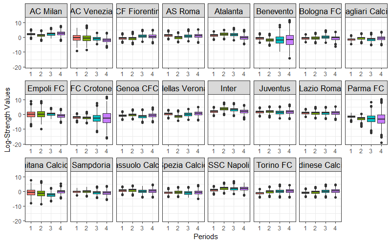

```r
# Dynamic Ranking

plot_btdPosterior(fit_result_dyn)
```

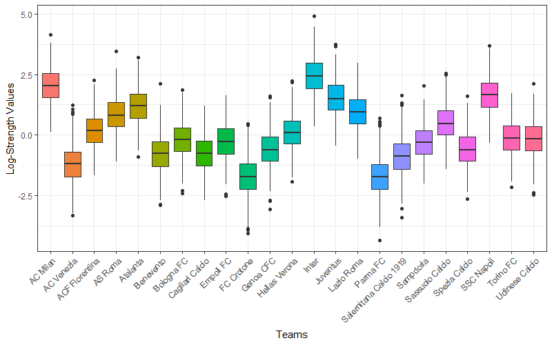

```r
# Static Ranking

plot_btdPosterior(fit_result_stat)
```

It is also possible to select specific teams to plot by using the `teams` argument

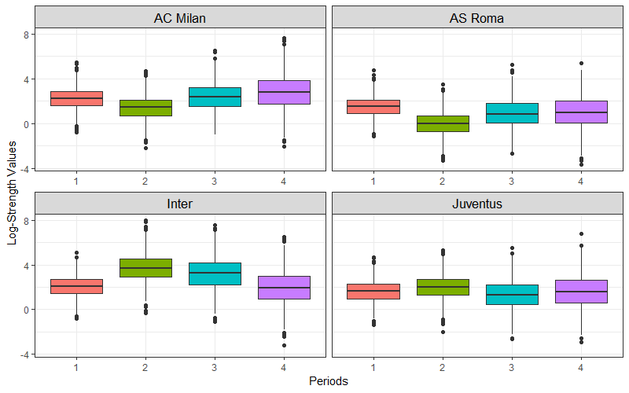

```r
# Dynamic Ranking

plot_btdPosterior(fit_result_dyn,
                  teams = c("AC Milan", "AS Roma", "Juventus", "Inter"),
                  ncol = 2)
```

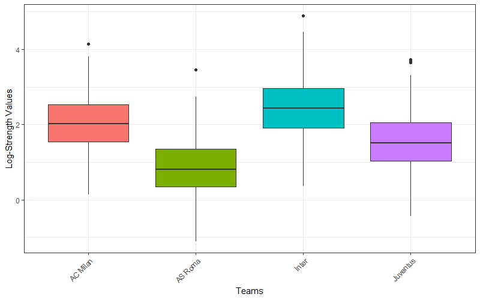

```r
# Static Ranking

plot_btdPosterior(fit_result_stat,
                  teams = c("AC Milan", "AS Roma", "Juventus", "Inter"),
                  ncol = 2)
```

Additionally, it is possible to plot the posterior density by setting `plot_type = "density"`

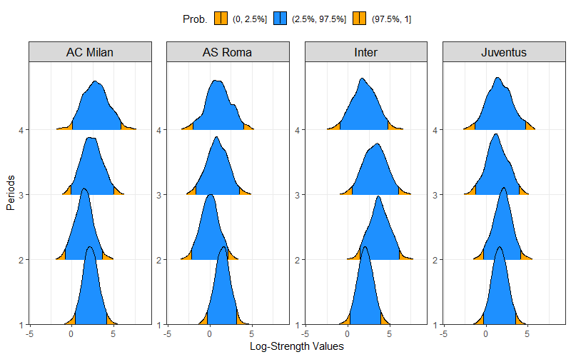

```r
# Dynamic Ranking

plot_btdPosterior(fit_result_dyn,
                  teams = c("AC Milan", "AS Roma", "Juventus", "Inter"),
                  plot_type = "density",
                  scales = "free_y")
```

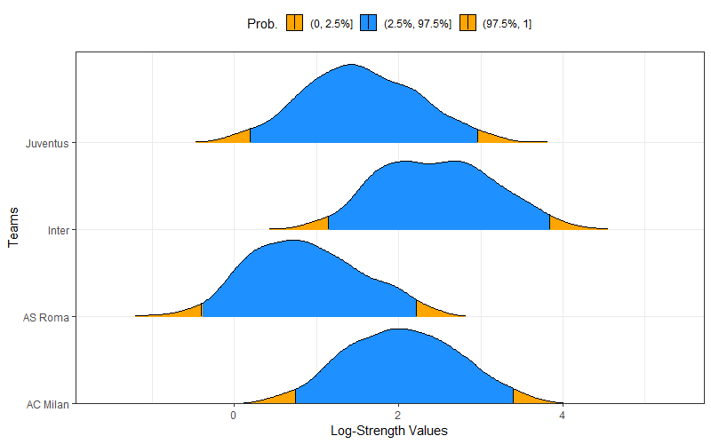

```r
# Static Ranking

plot_btdPosterior(fit_result_stat,
                  teams = c("AC Milan", "AS Roma", "Juventus", "Inter"),
                  plot_type = "density",
                  scales = "free_y")
```

Furthermore, the `plot_logStrength` function allows for plotting team rankings based on different summary measures of the posterior log-strengths, including the median, mean, and maximum a posteriori (MAP) estimates used in the `btd_foot` function. Specifically, this function generates a ggplot object that represents the log-strength values of teams, facilitating the comparison of team performance across different periods or among various teams. Similar to the `plot_btdPosterior` function, specific teams can be selected using the `teams` argument.

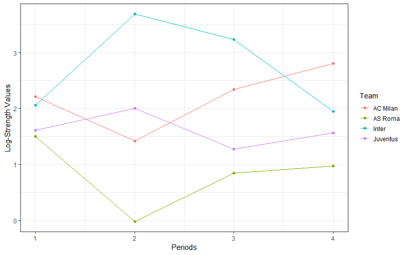

```r
# Dynamic Ranking

plot_logStrength(fit_result_dyn,
                  teams = c("AC Milan", "AS Roma", "Juventus", "Inter"))
```

# Goal-based models fit

## Static fit

To start with some analysis, let’s now `italy` data about the Italian Serie A, specifically season 2000/2001: the season consists of $T=18$ teams, we start fitting a static bivariate Poisson model using:

- The likelihood approach: the `mle_foot` function returns the MLE estimates along with 95% profile-likelihood deviance confidence intervals (by default) and Wald-type confidence intervals. The user can specify the desired confidence interval with the optional argument `interval = c("profile", "Wald")`.
- The Bayesian approach: the `stan_foot` function produces an Hamiltonian Monte Carlo posterior sampling by using the underlying `rstan` ecosystem. The user can choose the number of iterations (`iter`), the number of Markov chains (`chains`), and other optional arguments values. The output is an object of class `stanFoot`.

At this stage, we are currently ignoring any time-dependence in our parameters, considering them to be **static** across distinct match-times.

```r
### Use Italian Serie A 2000/2001

## with 'tidyverse' environment
#
#library(tidyverse)
#italy <- as_tibble(italy)
#italy_2000<- italy %>%
#  dplyr::select(Season, home, visitor, hgoal,vgoal) #%>%
#  dplyr::filter(Season=="2000")
#italy_2000

## alternatively, you can use the basic 'subsetting' code,
## not using the 'tidyverse' environment:
data("italy")
italy <- as.data.frame(italy)
italy_2000 <- subset(italy[, c(2,3,4,6,7)],
                     Season =="2000")

colnames(italy_2000) <- c("periods", "home_team", "away_team", "home_goals", "away_goals")


### Fit Stan models
## no dynamics, no predictions
## 4 Markov chains, 'n_iter' iterations each

n_iter <- 200    # number of MCMC iterations
fit1_stan <- stan_foot(data = italy_2000,
                       model="biv_pois",
                       chains = 4,
                       #cores = 4,
                       iter = n_iter) # biv poisson
```

Similarly to the `btd_foot` function, the custom `print` function for an object of class `stanFoot` provides the usual Bayesian model summaries , including posterior means, medians, standard deviations, percentiles at 2.5%, 25%, 75%, 97.5% level, effective sample size (`n_eff`) and Gelman-Rubin statistic (`Rhat`). It accepts the same arguments as described previously.

```r
## Print of model summary for parameters:

print(fit1_stan,
      pars = c("home", "rho", "sigma_att",
               "sigma_def", "att", "def"),
      teams = c("AC Milan", "AS Roma"))
```

```
#> Summary of Stan football model
#> ------------------------------
#>
#> Posterior summaries for model parameters:
#>                 mean se_mean    sd   2.5%    25%    50%    75%  97.5%   n_eff
#> home           0.281   0.004 0.069  0.139  0.234  0.284  0.329  0.401 345.009
#> rho           -1.747   0.018 0.311 -2.489 -1.916 -1.686 -1.544 -1.258 285.715
#> sigma_att      0.215   0.006 0.066  0.095  0.173  0.210  0.255  0.353 107.260
#> sigma_def      0.223   0.006 0.072  0.116  0.169  0.212  0.257  0.410 162.506
#> att[AS Roma]   0.278   0.008 0.121  0.054  0.186  0.273  0.365  0.500 232.482
#> att[AC Milan]  0.130   0.005 0.124 -0.116  0.042  0.127  0.219  0.368 537.002
#> def[AS Roma]  -0.205   0.007 0.142 -0.499 -0.282 -0.200 -0.110  0.051 471.159
#> def[AC Milan]  0.001   0.005 0.118 -0.231 -0.075  0.002  0.086  0.216 689.605
#>                Rhat
#> home          1.011
#> rho           1.000
#> sigma_att     1.022
#> sigma_def     1.027
#> att[AS Roma]  1.019
#> att[AC Milan] 1.000
#> def[AS Roma]  0.998
#> def[AC Milan] 0.997
```

The **Gelman-Rubin statistic** $\hat{R}$ (`Rhat`) is below the threshold 1.1 for all the parameters, whereas the **effective sample size** (`n_eff`), measuring the approximate number of iid replications from the Markov chains, does not appear to be problematic. Thus, HMC sampling reached the convergence.

As we could expect, there is a positive effect from the home-effect (posterior mean about 0.3), and this implies that if two teams are equally good (meaning that their attack and defence abilities almost coincide), assuming that the constant intercept $\mu \approx 0$, we get that the average number of goals for the home-team will be $\lambda_{1} = \exp \{0.3 \} \approx 1.35$, against $\lambda_{2} = \exp \{0 \} = 1$.

In the model above, we are assuming that the covariance $\lambda_{3n}$ is constant and not depending on the match and/or on teams characteristics/further covariates:

We can also depict the marginal posterior distributions for $\rho$ (and eventually for the other fixed-effects parameters) using the `bayesplot` package for Bayesian visualizations:

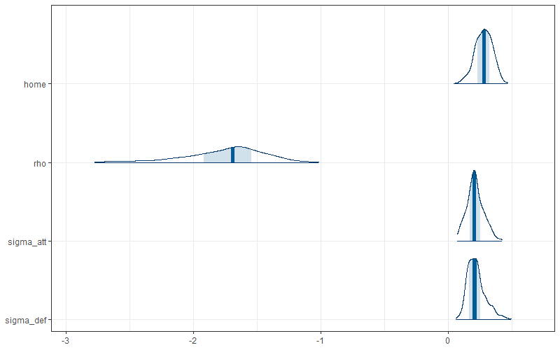

```r
## Marginal posterior with bayesplot

posterior1 <- as.matrix(fit1_stan$fit)
mcmc_areas(posterior1, regex_pars=c("home", "rho",
  "sigma_att", "sigma_def")) +
  theme_bw()
```

We can also access the original BP Stan code by typing:

```r
### Model's code extraction

fit1_stan$stan_code
```

```
#> S4 class stanmodel 'anon_model' coded as follows:
#> functions{
#>       real bipois_lpmf(array[] int r , real mu1,real mu2,real mu3) {
#>         real ss;
#>         real log_s;
#>         real mus;
#>         int  miny;
#>         miny = min(r[1], r[2]);
#>         ss = poisson_lpmf(r[1] | mu1) + poisson_lpmf(r[2] | mu2) -
#>           exp(mu3);
#>         if(miny > 0) {
#>           mus = -mu1-mu2+mu3;
#>           log_s = ss;
#>           for(k in 1:miny) {
#>             log_s = log_s + log(r[1] - k + 1) + mus
#>             + log(r[2] - k + 1)
#>             - log(k);
#>             ss = log_sum_exp(ss, log_s);
#>           }
#>         }
#>         return(ss);
#>       }
#>     }
#>     data{
#>       int N;   // number of games
#>       array[N,2] int y;
#>       int nteams;
#>       array[N]int instants_rank;
#>       int ntimes_rank;                 // dynamic periods for ranking
#>       array[N] int team1;
#>       array[N] int team2;
#>       matrix[ntimes_rank,nteams] ranking;
#>       int<lower=0, upper=1> ind_home;
#>       real mean_home;              // Mean for home effect
#>       real<lower=0> sd_home;      // Standard deviation for home effect
#>       // priors part
#>       int<lower=1,upper=4> prior_dist_num;    // 1 gaussian, 2 t, 3 cauchy, 4 laplace
#>       int<lower=1,upper=4> prior_dist_sd_num; // 1 gaussian, 2 t, 3 cauchy, 4 laplace
#>       real hyper_df;
#>       real hyper_location;
```

[output cut: 81 more lines]

```
#>     generated quantities{
#>       array[N,2] int y_rep;
#>       vector[N] log_lik;
#>       array[N] int diff_y_rep;
#>       //in-sample replications
#>       for (n in 1:N){
#>         y_rep[n,1] = poisson_rng(theta[n,1]+theta[n,3]);
#>         y_rep[n,2] = poisson_rng(theta[n,2]+theta[n,3]);
#>         diff_y_rep[n] = y_rep[n,1] - y_rep[n,2];
#>         log_lik[n] = poisson_lpmf(y[n,1]|theta[n,1]+theta[n,3])+
#>                      poisson_lpmf(y[n,2]|theta[n,2]+theta[n,3]);
#>        //log_lik[n] =bipois_lpmf(y[n,]| theta[n,1],
#>                 //                 theta[n,2], theta[n,3]);
#>       }
#>     }
```

We fit now the same model under the MLE approach with Wald-type confidence intervals. We can then print the MLE estimates, e.g for the parameters $\rho$ and $\text{home}$:

```r
### Fit MLE models
## no dynamics, no predictions
## Wald intervals

fit1_mle <- mle_foot(data = italy_2000,
                     model="biv_pois",
                     interval = "Wald") # mle biv poisson
fit1_mle$home_effect
```

```
#>      2.5% mle 97.5%
#> [1,]  0.2 0.3  0.39
```

We got a very similar estimate to the Bayesian model for the home-effect.

### Changing default priors

One of the common practices in Bayesian statistics is to change the priors and perform some **sensitivity tests**. The default priors for the team-specific abilities and their related team-level standard deviations are:

$$\begin{align}
\text{att}_t &\sim \mathrm{N}(\mu_{\text{att}},
\sigma_{\text{att}}),\\
\text{def}_t &\sim \mathrm{N}(\mu_{\text{def}},
\sigma_{\text{def}}),\\
\sigma_{\text{att}}, \sigma_{\text{def}} &\sim
\mathsf{Cauchy}^+(0,5),
\end{align}$$

where $\mathsf{Cauchy}^+$ denotes the half-Cauchy distribution with support $[0, +\infty)$. However, the user is free to elicit some different priors, possibly choosing one among the following distributions: Gaussian (`normal`), student-$t$ (`student_t`), Cauchy (`cauchy`) and Laplace (`laplace`). The `ability` optional argument allows to specify the priors for the team-specific parameters $\text{att}$ and $\text{def}$, whereas the optional argument `ability_sd` allows to assign a prior to the group-level standard deviations $\sigma_{\text{att}}, \sigma_{\text{def}}$. For instance, for each team $t, t=1,\ldots,T$, we could consider:

$$\begin{align}
\text{att}_t &\sim t(4, \mu_{\text{att}}, \sigma_{\text{att}}),\\
\text{def}_t &\sim t(4, \mu_{\text{def}}, \sigma_{\text{def}}),\\
\sigma_{\text{att}}, \sigma_{\text{def}} &\sim
\mathsf{Laplace}^+(0,1),
\end{align}$$

where $t(\text{df}, \mu, \sigma)$ denotes a student-$t$ distribution with df degrees of freedom, location $\mu$ and scale $\sigma$, whereas $\mathsf{Laplace}^+$ denotes a half-Laplace distribution.

```r
### Fit Stan models
## changing priors
## student-t for team-specific abilities, laplace for sds

fit1_stan_t <- stan_foot(data = italy_2000,
                         model="biv_pois",
                         chains = 4,
                         prior_par = list(
                           ability = student_t(4,0,NULL),
                           ability_sd = laplace(0,1),
                           home = normal(0, 10)),
                         #cores = 4,
                         iter = n_iter) # biv poisson
```

Then, we can compare the marginal posteriors from the two models, the one with Gaussian team-specific abilities and the default $\mathsf{Cauchy}(0,5)$ for the team-level sds, and the other one specified above, with student-$t$ distributed team-specific abilities and the $\mathsf{Laplace}^+(0,1)$ for the team-level sds. We depict here the comparison for the attack team-level sds only:

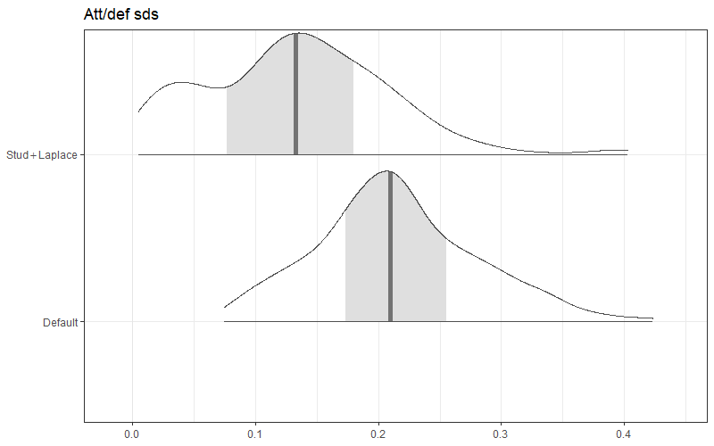

```r
## comparing posteriors

posterior1_t <- as.matrix(fit1_stan_t$fit)
model_names <- c("Default", "Stud+Laplace")
color_scheme_set(scheme = "gray")
gl_posterior <- cbind(posterior1[,"sigma_att"],
                      posterior1_t[,"sigma_att"])
colnames(gl_posterior)<-c("sigma_att", "sigma_att_t")
mcmc_areas(gl_posterior, pars=c("sigma_att", "sigma_att_t")) +
  xaxis_text(on =TRUE, size=ggplot2::rel(2.9)) +
  yaxis_text(on =TRUE, size=ggplot2::rel(2.9)) +
  scale_y_discrete(labels = ((parse(text= model_names)))) +
  ggtitle("Att/def sds") +
  theme(plot.title = element_text(hjust = 0.5, size =rel(2.6))) +
  theme_bw()
```

The student+laplace prior induces a lower amount of group-variability in the $\sigma_{\text{att}}$ marginal posterior distribution (then, a larger shrinkage towards the grand mean $\mu_{\text{att}}$).

When specifying the prior for the team-specific parameters through the argument `ability`, you are not allowed to fix the group-level standard deviations $\sigma_{\text{att}}, \sigma_{\text{def}}$ to some numerical values. Rather, they need to be assigned a reasonable prior distribution. For such reason, the most appropriate specification for the `ability` argument is `ability = 'dist'(0, NULL)`, where the scale argument is set to `NULL` (otherwise, a warning message is occurring).

## Dynamic fit

A structural limitation in the previous models is the assumption of static team-specific parameters, namely teams are assumed to have a constant performance across time, as determined by the attack and defence abilities (att, def). However, teams’ performance tend to be *dynamic* and change across different years, if not different weeks. Many factors contribute to this football aspect:

1. teams act during the summer/winter players’ transfermarket, by dramatically changing their rosters;
2. some teams’ players could be injured in some periods, by affecting the global quality of the team in some matches;
3. coaches could be dismissed from their teams due to some non satisfactory results;
4. some teams could improve/worsen their attitudes due to the so-called turnover;

and many others. Again, we could assume **dynamics** in the attach/defence abilities as in Owen (2011) , Egidi, Pauli, and Torelli (2018) and Macrı̀ Demartino, Egidi, and Torelli (2024) in terms of weeks or seasons. In such framework, for a given number of times $1, \ldots, \mathcal{T}$, the models above would be unchanged, but the priors for the abilities parameters at each time $\tau, \tau=2,\ldots, \mathcal{T},$ would be **auto-regressive** of order 1:

$$\begin{align}
\text{att}_{t, \tau} & \sim \mathrm{N}({\text{att}}_{t, \tau-1},
\sigma_{\text{att}})\\
\text{def}_{t, \tau} &\sim \mathrm{N}({\text{def}}_{t, \tau-1},
\sigma_{\text{def}}),
\end{align}$$

whereas for $\tau=1$ we have:

$$\begin{align}
\text{att}_{t, 1} & \sim \mathrm{N}(\mu_{\text{att}},
\sigma_{\text{att}})\\
\text{def}_{t, 1} &\sim \mathrm{N}(\mu_{\text{def}},
\sigma_{\text{def}}),
\end{align}$$

with hyperparameters $\mu_{\text{att}}, \mu_{\text{def}}, \sigma_{\text{att}}, \sigma_{\text{def}}$ and with the standard deviations capturing the time’s/evolution’s variation of both the teams’ skills (here assumed to be constant across time and teams). Of course, the identifiability constraint must be imposed for each time $\tau$.

```r
### Fit Stan models
## seasonal dynamics, no predictions
## 4 Markov chains, 'n_iter' iterations each

fit2_stan <- stan_foot(data = italy_2000,
                       model="biv_pois",
                       dynamic_type ="weekly",
                       #cores = 4,
                       iter = n_iter) # biv poisson
```

```r
print(fit2_stan, pars =c("home", "rho", "sigma_att",
                        "sigma_def"))
```

```
#> Summary of Stan football model
#> ------------------------------
#>
#> Posterior summaries for model parameters:
#>             mean se_mean    sd   2.5%    25%    50%    75%  97.5%   n_eff  Rhat
#> home       0.255   0.006 0.073  0.118  0.208  0.257  0.304  0.389 133.815 1.049
#> rho       -1.701   0.013 0.283 -2.322 -1.885 -1.694 -1.482 -1.228 485.525 1.001
#> sigma_att  0.062   0.005 0.014  0.042  0.052  0.060  0.071  0.092   8.466 1.672
#> sigma_def  0.072   0.013 0.022  0.034  0.053  0.076  0.088  0.111   3.027 2.575
```

From the printed summary, we may note that the degree of goals’ correlation seems to be again very small here. Moreover, the Gelman-Rubin statistic for $\sigma_{\text{att}}$ is relatively high, whereas the effective sample sizes for $\sigma_{\text{att}}$ and $\sigma_{\text{def}}$ are quite low. This is suggesting possible inefficiencies during the HMC sampling and that a *model-reparametrization* could be suited and effective at this stage. Another option is to play a bit with the prior specification for $\sigma_{\text{att}}$ and $\sigma_{\text{def}}$, for instance by specifying a prior inducing less shrinkage in the team-specific abilities.

To deal with these issues and broaden the set of candidate models, let’s fit also a dynamic double-Poisson model with the `double_pois` option for the argument `model`:

```r
### Fit Stan models
## weekly dynamics, no predictions
## 4 chains, 'n_iter' iterations each

fit3_stan <- stan_foot(data = italy_2000,
                       model="double_pois",
                       dynamic_type = "weekly",
                       #cores = 4,
                       iter = n_iter)  # double poisson
```

```r
print(fit3_stan, pars =c("home", "sigma_att",
                        "sigma_def"))
```

```
#> Summary of Stan football model
#> ------------------------------
#>
#> Posterior summaries for model parameters:
#>            mean se_mean    sd  2.5%   25%   50%   75% 97.5%   n_eff  Rhat
#> home      0.394   0.003 0.052 0.286 0.362 0.394 0.432 0.491 242.866 1.017
#> sigma_att 0.059   0.005 0.013 0.035 0.052 0.059 0.066 0.087   6.136 2.032
#> sigma_def 0.064   0.004 0.013 0.035 0.056 0.065 0.073 0.089  11.428 1.576
```

The fitting problems mentioned above remain also for the double Poisson model…Thus, it’s time to play a little bit with the prior distributions. Also in the dynamic approach we can change the default priors for the team-specific abilities and their standard deviations, respectively, through the optional arguments `ability` and `ability_sd`. The specification follows almost analogously the static case: with the first argument we may specify the prior’s family for the team-specific abilities and the specific priors for $\text{att}_{t,1}, \text{def}_{t,1}$ along with the hyper-prior location $\mu_{\text{att}}, \mu_{\text{def}}$, whereas $\sigma_{\text{att}}$ and $\sigma_{\text{def}}$ need to be assigned some proper prior distribution. Assume to fit the same double Poisson model, but here we suppose student-$t$ distributed team-specific abilities with 4 degrees of freedom to eventually capture more extreme team-specific abilities (more variability, i.e. less shrinkage), along with a $\text{Cauchy}^+(0,25)$ for their standard deviations (to better capture a possible larger evolution variability):

$$\begin{align}
\text{att}_{t, \tau} &\ \sim t(4, {\text{att}}_{t, \tau-1},
\sigma_{\text{att}})\\
\text{def}_{t, \tau} &\ \sim t(4, {\text{def}}_{t, \tau-1},
\sigma_{\text{def}})\\
\sigma_{\text{att}}, \sigma_{\text{def}} &\ \sim
\mathsf{Cauchy}^+(0,25),
\end{align}$$

```r
### Fit Stan models
## weekly dynamics, no predictions
## 4 chains, 'n_iter' iterations each

fit3_stan_t <- stan_foot(data = italy_2000,
                model="double_pois",
                prior_par = list(
                  ability = student_t(4,0,NULL),
                  ability_sd = cauchy(0,25),
                  home = normal(0, 5)),
                dynamic_type = "weekly",
                #cores = 4,
                iter = n_iter)  # double poisson
```

```r
print(fit3_stan_t, pars =c("home", "sigma_att",
                           "sigma_def"))
```

```
#> Summary of Stan football model
#> ------------------------------
#>
#> Posterior summaries for model parameters:
#>            mean se_mean    sd  2.5%   25%   50%   75% 97.5%   n_eff  Rhat
#> home      0.389   0.003 0.048 0.295 0.357 0.388 0.422 0.484 342.589 1.023
#> sigma_att 0.061   0.006 0.017 0.038 0.047 0.056 0.073 0.099   8.070 1.894
#> sigma_def 0.054   0.005 0.013 0.031 0.043 0.054 0.065 0.079   8.219 1.754
```

As we may conclude, the situation has been only slightly improved.

# Using `btd_foot` and `stan_foot` sequentially

One of the main features of the `footBayes` package is the ability to first compute the log-strengths using the Bayesian Bradley-Terry-Davidson model through the `btd_foot` function and then fit a Bayesian goal-based model using the `stan_foot` by passing the previously estimated historical team strengths as an additional covariate via the `ranking` argument. Specifically, this argument accepts an element of class `btdFoot`or alternatively a data frame with the following columns:

- `periods`: Time periods corresponding to the rankings (integer >= 1),
- `team`: Team names matching those in data (character string),
- `rank_points`: Ranking points (relative strengths) for each team (numeric).

The ability to use either `btdFoot` objects or custom ranking data frames provides flexibility in how the user can model team strengths, allowing for the integration of various ranking systems, such as the [FIFA ranking](https://inside.fifa.com/fifa-world-ranking).

```r
# Dynamic Bradley-Terry-Davidson model

data("italy")

 italy_2020_2021_rank <- italy %>%
   dplyr::select(Season, home, visitor, hgoal, vgoal) %>%
   dplyr::filter(Season == "2020" | Season == "2021") %>%
   dplyr::mutate(match_outcome = dplyr::case_when(
     hgoal > vgoal ~ 1,        # Home team wins
     hgoal == vgoal ~ 2,       # Draw
     hgoal < vgoal ~ 3         # Away team wins
   )) %>%
   dplyr::filter(dplyr::row_number() <= 570) %>%
   dplyr::mutate(periods = dplyr::case_when(
     dplyr::row_number() <= 190 ~ 1,
     dplyr::row_number() <= 380 ~ 2,
     dplyr::row_number() <= 570 ~ 3
   )) %>%
   dplyr::select(periods, home_team = home,
    away_team = visitor, match_outcome)



 fit_btd_dyn <- btd_foot(
   data = italy_2020_2021_rank,
   dynamic_rank = TRUE,
   rank_measure = "median",
   iter = 1000,
   #cores = 2,
   chains = 2,
   control = list(adapt_delta = 0.9,
                  max_treedepth = 12)
 )

# Dynamic Bivariate Poisson Model

 italy_2020_2021_fit <- italy %>%
   dplyr::select(Season, home, visitor, hgoal, vgoal) %>%
   dplyr::filter(Season == "2020" | Season == "2021")  %>%
   dplyr::filter(dplyr::row_number() <= 570) %>%
   dplyr::mutate(periods = dplyr::case_when(
     dplyr::row_number() <= 190 ~ 1,
     dplyr::row_number() <= 380 ~ 2,
     dplyr::row_number() <= 570 ~ 3
   )) %>%  # Assign periods based on match number
   dplyr::select(periods, home_team = home,
    away_team = visitor, home_goals = hgoal, away_goals = vgoal)



 fit_stan_rank <- stan_foot(data = italy_2020_2021_fit,
                           model="biv_pois",
                           ranking = fit_btd_dyn,
                           predict = 180,
                           prior_par = list(
                             ability = student_t(4,0,NULL),
                             ability_sd = cauchy(0,25),
                             home = normal(0, 5)),
                           dynamic_type = "season",
                           #cores = 4,
                           iter = 1000)
```

```r
print(fit_stan_rank,
      pars = c("home","rho","sigma_att", "sigma_def"))
```

```
#> Summary of Stan football model
#> ------------------------------
#>
#> Posterior summaries for model parameters:
#>             mean se_mean    sd   2.5%    25%    50%    75%  97.5%    n_eff
#> home       0.158   0.002 0.067  0.017  0.117  0.161  0.203  0.286 1383.141
#> rho       -1.095   0.004 0.158 -1.435 -1.188 -1.079 -0.991 -0.805 1378.807
#> sigma_att  0.042   0.014 0.031  0.004  0.017  0.035  0.058  0.118    5.106
#> sigma_def  0.037   0.005 0.022  0.006  0.019  0.034  0.051  0.088   23.201
#>            Rhat
#> home      1.003
#> rho       1.001
#> sigma_att 1.397
#> sigma_def 1.230
```

# Model estimates and visualization tools

## Plotting and interpreting team-specific abilities

Once the model has been fitted, there is a large amount of interesting summaries to explore. The function `foot_abilities` allows to depict posterior/confidence intervals for global attack and defense abilities on the considered data (attack abilities are plotted in red, whereas defense abilities in blue colors). The *higher the attack and the lower the defence* for a given team, and *the better is the overall team’s strength*.

We can produce the team-specific abilities for the two static fits above, `fit1_mle` (MLE) and `fit1_stan` (Bayes), with red bars for the attack and blue bars for the defence, respectively:

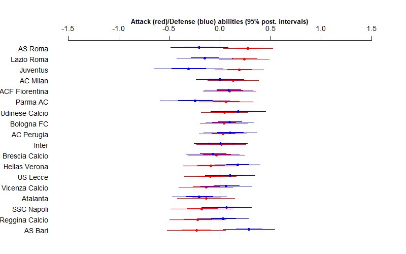

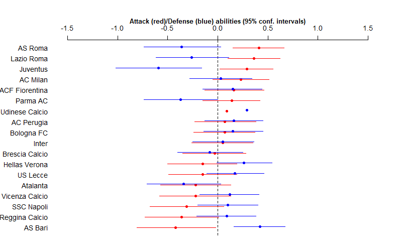

```r
## Plotting abilities: credible and confidence 95% intervals

foot_abilities(object = fit1_stan, data = italy_2000, cex.var = 1)
foot_abilities(object = fit1_mle, data = italy_2000, cex.var = 1)
```

We can also depict the team-specific dynamic plots for the dynamic models:

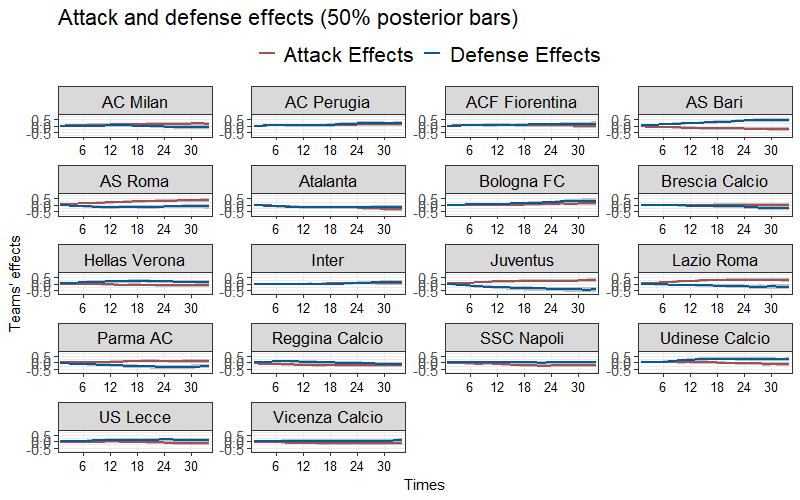

```r
## Plotting abilities: credible and confidence 95% intervals

foot_abilities(fit2_stan, italy_2000)
```

As we can see, dynamic abilities naturally evolve over the time: better teams (AS Roma, Lazio Roma, Juventus, Parma) are associated with increasing attack abilities and decreasing defence abilities, whereas the worst ones (AS Bari, SSC NApoli, and Hellas Verona) exhibit decreasing attacking skills and increasing defensive skills. The reason for these increasing/decreasing behaviours is straightforward: at the beginning, all the attack/defence parameters have been initialized to have location equal to 0. The user is free to change the location, and in the final package’s version he will also have the possibility to elicit different team-specific hyper-prior locations.

# Model checking

Checking the model fit is a relevant and vital statistical task. To this purpose, we can evaluate hypothetical replications $\mathcal{D}^{\text{rep}}$ under the **posterior predictive distribution**

$$p(\mathcal{D}^{\text{rep}}| \mathcal{D})
= \int p(\mathcal{D}^{\text{rep}}| \boldsymbol{\theta})
\pi(\boldsymbol{\theta}| \mathcal{D}) d\boldsymbol{\theta},$$
and check whether these replicated values are somehow close to the observed data $\mathcal{D}$. These methods comparing hypothetical replications with the observed data are named **posterior predictive checks** and have great theoretical and applied appeal in Bayesian inference. See Gelman et al. (2014) for an overview.

The function `pp_foot` allows to obtain:

- an aggregated plot depicting the observed frequencies of the observed goal differences $Z_n=X_n-Y_n, \ n=1,\ldots,N$ plotted against the replicated ones;
- a visualization of the match-ordered goal differences along with their 50% and 95% credible intervals.

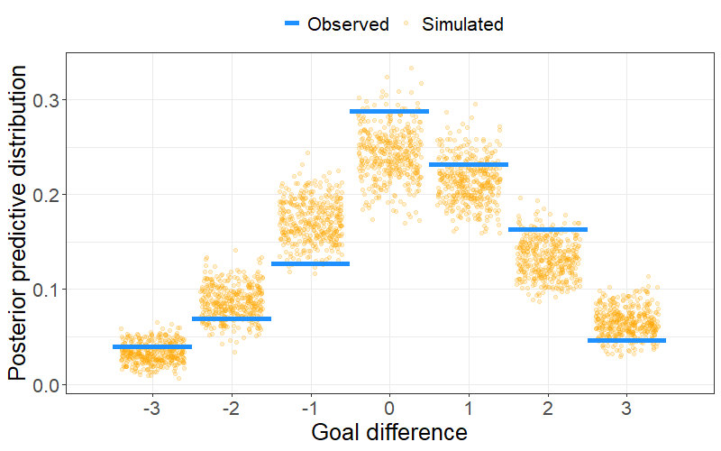

```
#>
#> $pp_table
#>   goal diff. Bayesian p-value
#> 1         -3            0.330
#> 2         -2            0.875
#> 3         -1            0.990
#> 4          0            0.052
#> 5          1            0.225
#> 6          2            0.078
#> 7          3            0.927

pp_foot(object = fit1_stan, data = italy_2000,
        type = "matches")
#> $pp_plot
```

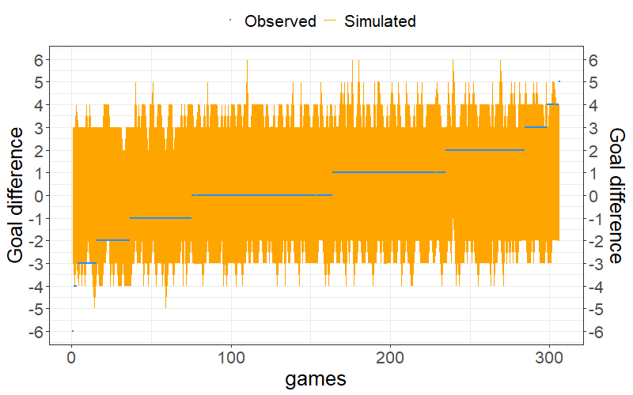

```
#>
#> $pp_table
#>   1-alpha emp. coverage
#> 1    0.95         0.941
```

```r
## PP checks: aggregated goal's differences and ordered goal differences

pp_foot(object = fit1_stan, data = italy_2000,
        type = "aggregated")
```

The aggregated goal difference frequencies seem to be decently captured by the model’s replications: in the first plot, blue horizontal lines denote the observed goal differences frequencies registered in the dataset, whereas yellow jittered points denote the correspondent replications. Goal-difference of 0, corresponding to the draws occurrences, is only slightly underestimated by the model. However, in general there are no particular clues of model’s misfit.

In the second plot, the ordered observed goal differences are plotted against their replications (50% and 95% credible intervals), and from this plot also we do not have particular signs of model’s misfits.

Other useful PP checks, such as the overlap between data density and replicated data densities to check eventual inconsistencies, can be obtained through the standard use of the `bayesplot` package, in this case providing an approximation to a continuous distribution using an input kernel choice (`bw = 0.5` in the `ppc_dens_overlay` used below):

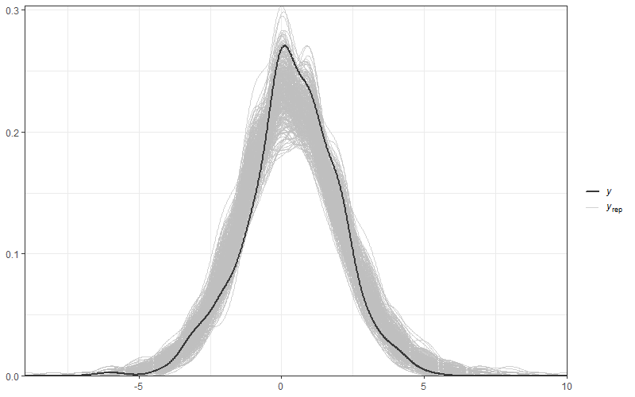

```r
## PPC densities overlay with the bayesplot package

# extracting the replications

sims <-rstan::extract(fit1_stan$fit)
goal_diff <- italy_2000$home_goals-italy_2000$away_goals

# plotting data density vs replications densities

ppc_dens_overlay(goal_diff, sims$y_rep[,,1]-sims$y_rep[,,2], bw = 0.5) +
    theme_bw()
```

From this plot above we have the empirical confirmation that the goal difference is well captured by the static bivariate Poisson model.

# Predictions and predictive accuracy

## Posterior out-of-sample probabilities

The hottest feature in sports analytics is to obtain future predictions. By considering the **posterior predictive distribution** for future and observable data $\tilde{\mathcal{D}}$, we acknowledge the whole model’s prediction uncertainty (which propagates from the posterior model’s uncertainty) and we can then generate observable values $\tilde{D}$ conditioned on the posterior model’s parameters estimates:

$$p(\tilde{\mathcal{D}}| \mathcal{D}) =
\int p(\tilde{\mathcal{D}}| \boldsymbol{\theta})
\pi(\boldsymbol{\theta}| \mathcal{D}) d\boldsymbol{\theta}.$$

We may then predict test set matches by using the argument `predict` of the `stan_foot` function, for instance considering the last four weeks of the 2000/2001 season as the test set, and then computing posterior-results probabilities using the function `foot_prob` for two teams belonging to the test set, such as Reggina Calcio and AC Milan:

```r
### Fit Stan models
## weekly dynamics, predictions of last four weeks
## 4 chains 'n_iter' iterations each

fit4_stan <- stan_foot(data = italy_2000,
                       model="biv_pois",
                       predict = 36,
                       dynamic_type = "weekly",
                       #cores = 4,
                       iter = n_iter)  # biv poisson
```

```r
foot_prob(object = fit4_stan, data = italy_2000,
          home_team = "Reggina Calcio",
          away_team= "AC Milan")
```

```
#> $prob_table
#>        home_team away_team prob_h prob_d prob_a         mlo
#> 1 Reggina Calcio  AC Milan  0.264  0.232  0.504 1-1 (0.118)
#>
#> $prob_plot
```

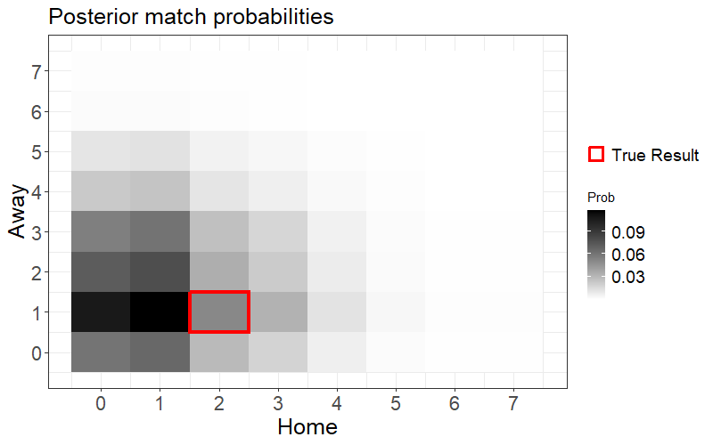

Darker regions are associated with higher posterior probabilities, whereas the red square corresponds to the actual observed result, 2-1 for Reggina Calcio. According to the posterior-results probabilities, this final observed result had in principle about a 5% probability to happen! (Remember, football is about rare events…).

## Home-win posterior probabilities

We can also use the out-of-sample posterior-results probabilities to compute some aggregated **home/draw/loss** probabilities (based then on the $S$ draws from the MCMC method) for a given match:

$$\begin{align}
p_{\text{home}}= &\ \textrm{Pr}(X>Y) = \frac{1}{S}\sum_{s=1}^S|
\tilde{x}^{(s)}> \tilde{y}^{(s)}|\\
p_{\text{draw}} = &\ \textrm{Pr}(X=Y) = \frac{1}{S}\sum_{s=1}^S|
\tilde{x}^{(s)}= \tilde{y}^{(s)}|\\
p_{\text{loss}} = &\ \textrm{Pr} (X<Y)=\frac{1}{S}\sum_{s=1}^S|
\tilde{x}^{(s)}< \tilde{y}^{(s)}|,
\end{align}$$

where $(\tilde{x}^{(s)}, \tilde{y}^{(s)})$ represents the $s$-th MCMC pair of the future home goals and away goals for a given match, respectively. According to this scenario, we can depict the home-win posterior probabilities of a given test set through the function `foot_round_robin`:

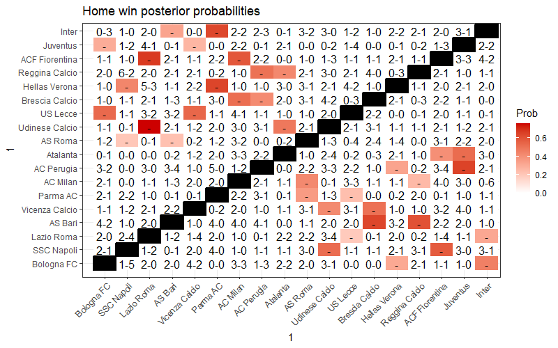

```
#>
#> $round_table
#> # A tibble: 36 × 4
#>    Home           Away           Home_prob Observed
#>    <chr>          <chr>          <chr>     <chr>
#>  1 Hellas Verona  Bologna FC     0.31      -
#>  2 Inter          Bologna FC     0.452     -
#>  3 Udinese Calcio SSC Napoli     0.52      -
#>  4 ACF Fiorentina SSC Napoli     0.578     -
#>  5 US Lecce       Lazio Roma     0.19      -
#>  6 Inter          Lazio Roma     0.315     -
#>  7 Brescia Calcio AS Bari        0.637     -
#>  8 Reggina Calcio AS Bari        0.605     -
#>  9 Udinese Calcio Vicenza Calcio 0.42      -
#> 10 Brescia Calcio Vicenza Calcio 0.505     -
#> # ℹ 26 more rows
```

```r
## Home win out-of-sample probabilities

foot_round_robin(object = fit4_stan, data = italy_2000)
```

## Rank-league reconstruction

Statisticians and football amateurs are much interested in the final rank-league predictions. However, predicting the final rank position (along with the teams’ points) is often assimilated to an *oracle*, rather than a coherent statistical procedure.

We can provide here:

- **rank-league reconstruction** for the first model `fit1_stan` by using the **in-sample** replications $\mathcal{D}^{\text{rep}}$ (yellow ribbons for the credible intervals, solid blue lines for the observed cumulated points):

```
#> $rank_table
#>             teams mid obs lo hi
#> 1         AS Roma  60  75 55 66
#> 2        Juventus  60  73 54 66
#> 3      Lazio Roma  58  69 52 64
#> 4        Parma AC  55  56 49 60
#> 5        AC Milan  50  49 44 57
#> 6  Brescia Calcio  48  44 43 54
#> 7           Inter  48  51 41 53
#> 8        Atalanta  47  44 42 53
#> 9  ACF Fiorentina  47  43 41 54
#> 10     Bologna FC  46  43 41 52
#> 11     AC Perugia  45  42 40 50
#> 12 Udinese Calcio  43  38 38 48
#> 13 Vicenza Calcio  42  36 35 48
#> 14       US Lecce  42  37 35 47
#> 15 Reggina Calcio  40  37 34 45
#> 16     SSC Napoli  40  36 34 46
#> 17  Hellas Verona  40  37 34 46
#> 18        AS Bari  33  20 27 39
#>
#> $rank_plot
```

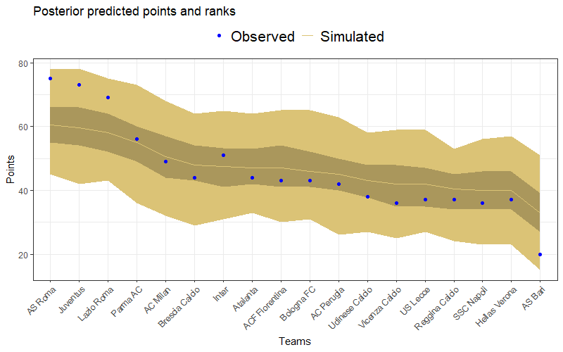

```r
## Rank league reconstruction

# aggregated plot

foot_rank(object = fit1_stan, data = italy_2000)
```

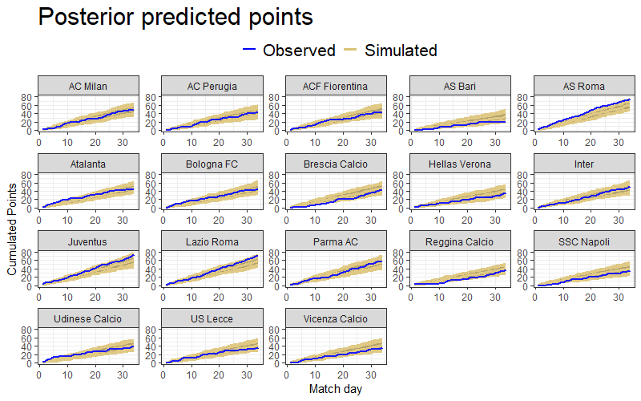

```r
# team-specific plot

foot_rank(object = fit1_stan, data = italy_2000,
          visualize = "individual")
```

- **rank-league prediction** (aggregated or at team-level) for the fourth model `fit4_stan` by using the **out-of-sample** replications $\tilde{\mathcal{D}}$ (yellow ribbons for the credible intervals, solid blue lines for the observed cumulated points):

```
#> $rank_table
#>             teams mid obs lo hi
#> 1         AS Roma  74  75 72 76
#> 2      Lazio Roma  71  69 68 72
#> 3        Juventus  68  73 66 70
#> 4        Parma AC  57  56 56 60
#> 5        AC Milan  54  49 52 56
#> 6           Inter  49  51 47 51
#> 7      Bologna FC  48  43 46 49
#> 8        Atalanta  48  44 45 49
#> 9      AC Perugia  46  42 43 47
#> 10 ACF Fiorentina  43  43 42 46
#> 11 Brescia Calcio  42  44 40 45
#> 12 Udinese Calcio  38  38 37 41
#> 13 Vicenza Calcio  37  36 35 39
#> 14       US Lecce  35  37 34 37
#> 15 Reggina Calcio  34  37 32 36
#> 16     SSC Napoli  32  36 30 34
#> 17  Hellas Verona  32  37 30 34
#> 18        AS Bari  23  20 21 25
#>
#> $rank_plot
```

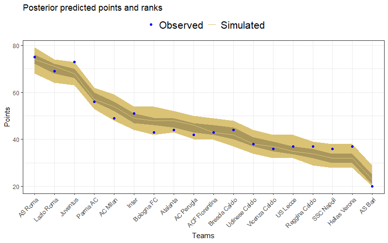

```r
## Rank predictions for individual teams

# aggregated plot

foot_rank(object = fit4_stan, data = italy_2000)
```

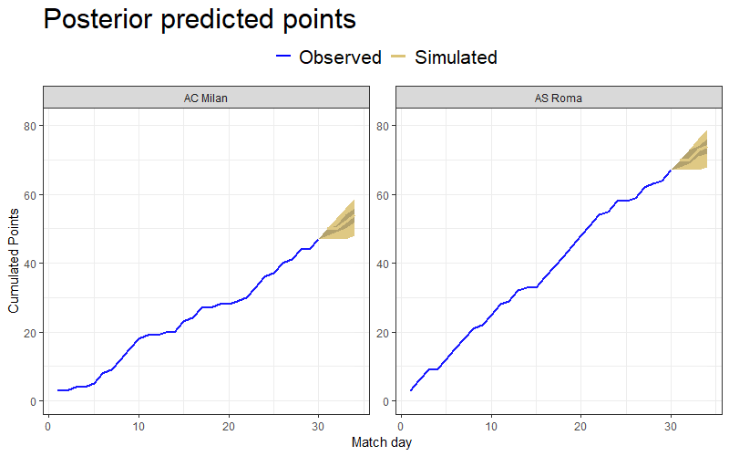

```r
# team-specific plot

foot_rank(object = fit4_stan, data = italy_2000,
          teams = c("AC Milan", "AS Roma"),
          visualize = "individual")
```

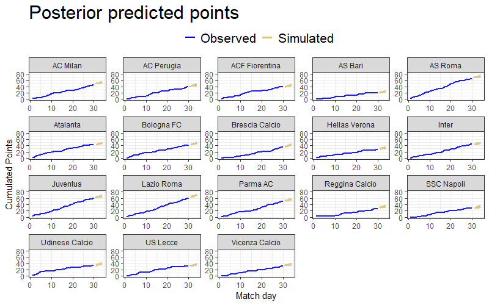

```r
foot_rank(object = fit4_stan, data = italy_2000,
          visualize = "individual")
```

# Model comparisons

## Comparing Football Prediction Models using `compare_foot`

Evaluating the performance of these models is crucial to understand their predictive power and reliability. The `compare_foot` function provides a comprehensive way to compare different models or probability matrices using metrics like accuracy, Brier score, ranked probability score (RPS), Pseudo $R^2$, and average coverage probability (ACP). It also offers the option to compute confusion matrices for a detailed performance analysis.

```r
italy_2020_2021_fit <- italy %>%
  dplyr::select(Season, home, visitor, hgoal, vgoal) %>%
  dplyr::filter(Season == "2020" | Season == "2021")  %>%
  dplyr::mutate(periods = dplyr::case_when(
    dplyr::row_number() <= 190 ~ 1,
    dplyr::row_number() <= 380 ~ 2,
    dplyr::row_number() <= 570 ~ 3,
    TRUE ~ 4
  )) %>%  # Assign periods based on match number
  dplyr::select(periods, home_team = home,
                away_team = visitor, home_goals = hgoal, away_goals = vgoal)


fit_comp_1 <- stan_foot(data = italy_2020_2021_fit,
                       model="biv_pois",
                       home_effect = TRUE,
                       predict = 190,
                       dynamic_type = "season",
                       #cores = 4,
                       iter = n_iter)

fit_comp_2 <- stan_foot(data = italy_2020_2021_fit,
                       model="double_pois",
                       home_effect = TRUE,
                       predict = 190,
                       dynamic_type = "season",
                       #cores = 4,
                       iter = n_iter)


italy_2020_2021_test <- italy %>%
  dplyr::select(Season, home, visitor, hgoal, vgoal) %>%
  dplyr::filter(Season == "2014" | Season == "2015")  %>%
  dplyr::mutate(periods = dplyr::case_when(
    dplyr::row_number() <= 190 ~ 1,
    dplyr::row_number() <= 380 ~ 2,
    dplyr::row_number() <= 570 ~ 3,
    TRUE ~ 4)) %>%
  dplyr::filter(dplyr::row_number() > 570) %>%
  dplyr::select(periods,
                home_team = home,
                away_team = visitor,
                home_goals = hgoal,
                away_goals = vgoal)
```

```r
compare_results_models <- compare_foot(
  source = list(biv_pois = fit_comp_1,
                double_pois = fit_comp_2),
  test_data = italy_2020_2021_test,
  metric = c("accuracy", "brier", "ACP", "pseudoR2", "RPS"),
  conf_matrix = TRUE)


print(compare_results_models, digits = 3)
```

```
#> Predictive Performance Metrics
#>        Model   RPS accuracy brier pseudoR2   ACP
#>     biv_pois 0.255    0.353 0.716    0.310 0.348
#>  double_pois 0.256    0.384 0.716    0.308 0.362
#>
#> Confusion Matrices
#> Model: biv_pois
#>
#>           Actual
#> Predicted  Home Win Draw Away Win
#>   Home Win       50   28       31
#>   Draw            0    0        0
#>   Away Win       39   25       17
#>
#> Model: double_pois
#>
#>           Actual
#> Predicted  Home Win Draw Away Win
#>   Home Win       59   35       34
#>   Draw            0    0        0
#>   Away Win       30   18       14
```

## LOOIC and WAIC

Comparing statistical models in terms of some **predictive information criteria** should conclude many analysis and can be carried out by using the Leave-one-out cross-validation criterion (**LOOIC**) and the Watanabe Akaike Information criterion (**WAIC**) performed by using the `loo` package. For more details about LOOIC and WAIC, read the paper Vehtari, Gelman, and Gabry (2017).

The general formulation for the predictive information criteria is the following:

$$\text{crit}=-2 \widehat{\text{elpd}}
= -2 (\widehat{\text{lpd}}- \text{parameters penalty})$$

- $\widehat{\text{elpd}}$: estimate of the expected log predictive density of the fitted model.
- $\widehat{\text{lpd}}$ is a measure of the log predictive density of the fitted model.
- parameters penalty is a penalization accounting for the effective number of parameters of the fitted model.

The interpretation is the following: the lower is the value for an information criterion, and the better is the estimated model’s predictive accuracy. Moreover, if two competing models share the same value for the log predictive density, the model with less parameters is favored.

This is the **Occam’s Razor** occurring in statistics:

> “Frustra fit per plura quod potest fieri per pauciora”

We can perform Bayesian model comparisons by using the `loo` and `waic` functions of the `loo` package. We are going to compare the static and the weekly dynamic models on the Italian Serie A 2000/2001:

```r
### Model comparisons
## LOOIC, loo function

# extract pointwise log-likelihood

log_lik_1 <- extract_log_lik(fit1_stan$fit)
log_lik_1_t <- extract_log_lik(fit1_stan_t$fit)
log_lik_2 <- extract_log_lik(fit2_stan$fit)
log_lik_3 <- extract_log_lik(fit3_stan$fit)
log_lik_3_t <- extract_log_lik(fit3_stan_t$fit)

# compute loo

loo1 <- loo(log_lik_1)
loo1_t <- loo(log_lik_1_t)
loo2 <- loo(log_lik_2)
loo3 <- loo(log_lik_3)
loo3_t <- loo(log_lik_3_t)


# compare three looic

loo_compare(loo1, loo1_t, loo2, loo3, loo3_t)
```

```
#>        elpd_diff se_diff
#> model1   0.0       0.0
#> model3  -5.1       2.7
#> model4  -6.5       4.1
#> model5  -9.0       4.1
#> model2 -50.3       4.7
```

# Extensions in next versions

Extensions and to-do list for the next package’s versions:

1. **Data Web-scraping**: automatic routine to scrape data from internet;
2. **More numerical outputs**: posterior probabilities, betting strategies, etc.;
3. **Diagnostics, pp checks** designed for football;
4. **Teams’ statistics**
5. **More covariates** to be included in the model (possibly by users).
6. **More priors choices**

# References

Baio, Gianluca, and Marta Blangiardo. 2010. “Bayesian Hierarchical Model for the Prediction of Football Results.” *Journal of Applied Statistics* 37 (2): 253–64.

Betancourt, Michael. 2017. “A Conceptual Introduction to Hamiltonian Monte Carlo.” *arXiv Preprint arXiv:1701.02434*.

Bradley, Ralph Allan, and Milton E. Terry. 1952. “Rank Analysis of Incomplete Block Designs: I. The Method of Paired Comparisons.” *Biometrika* 39 (3/4): 324–45.

Davidson, Roger R. 1970. “On Extending the Bradley-Terry Model to Accommodate Ties in Paired Comparison Experiments.” *Journal of the American Statistical Association* 65 (329): 317–28.

Davidson, Roger R., and Robert J. Beaver. 1977. “On Extending the Bradley-Terry Model to Incorporate Within-Pair Order Effects.” *Biometrics* 33 (4): 693–702. http://www.jstor.org/stable/2529467.

Egidi, Leonardo, Francesco Pauli, and Nicola Torelli. 2018. “Combining Historical Data and Bookmakers’ Odds in Modelling Football Scores.” *Statistical Modelling* 18 (5-6): 436–59.

Egidi, Leonardo, and Nicola Torelli. 2020. “Comparing Goal-Based and Result-Based Approaches in Modelling Football Outcomes.” *Social Indicators Research*, 1–13.

Gelman, Andrew. 2014. “Stan Goes to the World Cup.” *Statistical Modeling, Causal Inference, and Social Science Blog*. https://statmodeling.stat.columbia.edu/2014/07/13/stan-analyzes-world-cup-data/.

Gelman, Andrew, John B Carlin, Hal S Stern, and Donald B Rubin. 2014. *Bayesian Data Analysis*. Vol. 2. Chapman & Hall/CRC Boca Raton, FL, USA.

Groll, Andreas, Gunther Schauberger, and Gerhard Tutz. 2015. “Prediction of Major International Soccer Tournaments Based on Team-Specific Regularized Poisson Regression: An Application to the FIFA World Cup 2014.” *Journal of Quantitative Analysis in Sports* 11 (2): 97–115.

Issa Mattos, David, and Érika Martins Silva Ramos. 2022. “Bayesian Paired Comparison with the Bpcs Package.” *Behavior Research Methods* 54 (4): 2025–45. https://doi.org/10.3758/s13428-021-01714-2.

Karlis, Dimitris, and Ioannis Ntzoufras. 2003. “Analysis of Sports Data by Using Bivariate Poisson Models.” *Journal of the Royal Statistical Society: Series D (The Statistician)* 52 (3): 381–93.

———. 2009. “Bayesian Modelling of Football Outcomes: Using the Skellam’s Distribution for the Goal Difference.” *IMA Journal of Management Mathematics* 20 (2): 133–45.

Koopman, Siem Jan, and Rutger Lit. 2015. “A Dynamic Bivariate Poisson Model for Analysing and Forecasting Match Results in the English Premier League.” *Journal of the Royal Statistical Society: Series A (Statistics in Society)* 178 (1): 167–86.

Macrı̀ Demartino, Roberto, Leonardo Egidi, and Nicola Torelli. 2024. “Alternative Ranking Measures to Predict International Football Results.” *arXiv Preprint arXiv:2405.10247*.

Owen, Alun. 2011. “Dynamic Bayesian Forecasting Models of Football Match Outcomes with Estimation of the Evolution Variance Parameter.” *IMA Journal of Management Mathematics* 22 (2): 99–113.

Robert, Christian, and George Casella. 2013. *Monte Carlo Statistical Methods*. Springer Science & Business Media.

Stan Development Team. 2020. “RStan: The R Interface to Stan.” https://mc-stan.org/.

Vehtari, Aki, Andrew Gelman, and Jonah Gabry. 2017. “Practical Bayesian Model Evaluation Using Leave-One-Out Cross-Validation and WAIC.” *Statistics and Computing* 27 (5): 1413–32.

Whelan, John T. 2017. “Prior Distributions for the Bradley-Terry Model of Paired Comparisons.” *arXiv Preprint arXiv:1712.05311*.